# Milestone Project 1: Cleveland Heart Disease Dataset

Hello, I'm [JayaPrakash](https://jayaprakash6650.github.io/Personal-Website/index.html) and this is a part of the milestone project for my online course on Machine Learning. The dataset used is a modified version of the original one used by many to learn the various classifiers used in machine learning, "The Cleveland Heart Disease Dataset" - https://www.kaggle.com/datasets/cherngs/heart-disease-cleveland-uci.

**The methodology followed is explained below:**

1. Data description
2. Exploratory Data Analysis
3. Selecting the features of the classifier
4. Selecting the classifier
5. Evaluating the classifier
6. Tuning the classifier
7. Saving the model

**The tools used in this project are:**

1. Jupyter Notebook
2. Python
3. Pandas
4. Matplotlib
5. Numpy
6. Scikit-learn

# 1. Data Description

The dataset contains a total of 297 entries having 14 attributes. The attributes and their descriptions are as follows:

1. age: age in years
2. sex: sex (1 = male; 0 = female)
3. cp: chest pain type -- Value 0: typical angina -- Value 1: atypical angina -- Value 2: non-anginal pain -- Value 3: asymptomatic
4. trestbps: resting blood pressure (in mm Hg on admission to the hospital)
5. chol: serum cholestoral in mg/dl
6. fbs: (fasting blood sugar > 120 mg/dl) (1 = true; 0 = false)
7. restecg: resting electrocardiographic results -- Value 0: normal -- Value 1: having ST-T wave abnormality (T wave inversions and/or ST elevation or depression of > 0.05 mV) -- Value 2: showing probable or definite left ventricular hypertrophy by Estes' criteria
8. thalach: maximum heart rate achieved
9. exang: exercise induced angina (1 = yes; 0 = no)
10. oldpeak = ST depression induced by exercise relative to rest
11. slope: the slope of the peak exercise ST segment -- Value 0: upsloping -- Value 1: flat -- Value 2: downsloping
12. ca: number of major vessels (0-3) colored by flourosopy
13. thal: 0 = normal; 1 = fixed defect; 2 = reversable defect
14. condition: 0 = no disease, 1 = disease (The Target)

### The evaluation condition for the classifier will be set at 95% accuracy in predicting whether a given patient has heart disease based on the features above.

```python
#Import dependencies
import pandas as pd
import numpy as np
import matplotlib.pyplot as plt
%matplotlib inline
import seaborn as sns
initial_data = pd.read_csv("heart_disease.csv")
```

```python
initial_data.head(10)
```

|  | age | sex | cp | trestbps | chol | fbs | restecg | thalach | exang | oldpeak | slope | ca | thal | condition |
| --- | --- | --- | --- | --- | --- | --- | --- | --- | --- | --- | --- | --- | --- | --- |
| 0 | 69 | 1 | 0 | 160 | 234 | 1 | 2 | 131 | 0 | 0.1 | 1 | 1 | 0 | 0 |
| 1 | 69 | 0 | 0 | 140 | 239 | 0 | 0 | 151 | 0 | 1.8 | 0 | 2 | 0 | 0 |
| 2 | 66 | 0 | 0 | 150 | 226 | 0 | 0 | 114 | 0 | 2.6 | 2 | 0 | 0 | 0 |
| 3 | 65 | 1 | 0 | 138 | 282 | 1 | 2 | 174 | 0 | 1.4 | 1 | 1 | 0 | 1 |
| 4 | 64 | 1 | 0 | 110 | 211 | 0 | 2 | 144 | 1 | 1.8 | 1 | 0 | 0 | 0 |
| 5 | 64 | 1 | 0 | 170 | 227 | 0 | 2 | 155 | 0 | 0.6 | 1 | 0 | 2 | 0 |
| 6 | 63 | 1 | 0 | 145 | 233 | 1 | 2 | 150 | 0 | 2.3 | 2 | 0 | 1 | 0 |
| 7 | 61 | 1 | 0 | 134 | 234 | 0 | 0 | 145 | 0 | 2.6 | 1 | 2 | 0 | 1 |
| 8 | 60 | 0 | 0 | 150 | 240 | 0 | 0 | 171 | 0 | 0.9 | 0 | 0 | 0 | 0 |
| 9 | 59 | 1 | 0 | 178 | 270 | 0 | 2 | 145 | 0 | 4.2 | 2 | 0 | 2 | 0 |

```python
initial_data.describe()
```

|  | age | sex | cp | trestbps | chol | fbs | restecg | thalach | exang | oldpeak | slope | ca | thal | condition |
| --- | --- | --- | --- | --- | --- | --- | --- | --- | --- | --- | --- | --- | --- | --- |
| count | 297.000000 | 297.000000 | 297.000000 | 297.000000 | 297.000000 | 297.000000 | 297.000000 | 297.000000 | 297.000000 | 297.000000 | 297.000000 | 297.000000 | 297.000000 | 297.000000 |
| mean | 54.542088 | 0.676768 | 2.158249 | 131.693603 | 247.350168 | 0.144781 | 0.996633 | 149.599327 | 0.326599 | 1.055556 | 0.602694 | 0.676768 | 0.835017 | 0.461279 |
| std | 9.049736 | 0.468500 | 0.964859 | 17.762806 | 51.997583 | 0.352474 | 0.994914 | 22.941562 | 0.469761 | 1.166123 | 0.618187 | 0.938965 | 0.956690 | 0.499340 |
| min | 29.000000 | 0.000000 | 0.000000 | 94.000000 | 126.000000 | 0.000000 | 0.000000 | 71.000000 | 0.000000 | 0.000000 | 0.000000 | 0.000000 | 0.000000 | 0.000000 |
| 25% | 48.000000 | 0.000000 | 2.000000 | 120.000000 | 211.000000 | 0.000000 | 0.000000 | 133.000000 | 0.000000 | 0.000000 | 0.000000 | 0.000000 | 0.000000 | 0.000000 |
| 50% | 56.000000 | 1.000000 | 2.000000 | 130.000000 | 243.000000 | 0.000000 | 1.000000 | 153.000000 | 0.000000 | 0.800000 | 1.000000 | 0.000000 | 0.000000 | 0.000000 |
| 75% | 61.000000 | 1.000000 | 3.000000 | 140.000000 | 276.000000 | 0.000000 | 2.000000 | 166.000000 | 1.000000 | 1.600000 | 1.000000 | 1.000000 | 2.000000 | 1.000000 |
| max | 77.000000 | 1.000000 | 3.000000 | 200.000000 | 564.000000 | 1.000000 | 2.000000 | 202.000000 | 1.000000 | 6.200000 | 2.000000 | 3.000000 | 2.000000 | 1.000000 |

```python
initial_data.isna().sum()
```

```
age          0
sex          0
cp           0
trestbps     0
chol         0
fbs          0
restecg      0
thalach      0
exang        0
oldpeak      0
slope        0
ca           0
thal         0
condition    0
dtype: int64
```

### Since there is no missing data, and all the columns are numerical values, we can directly start assuming classifiers.

#### Usually we must clean the data for missing values and encode the categorical data before we can fit the model/classifier

# 2. Exploratory Data Analysis

We can visualise the various attributes of the data through the matplotlib library.

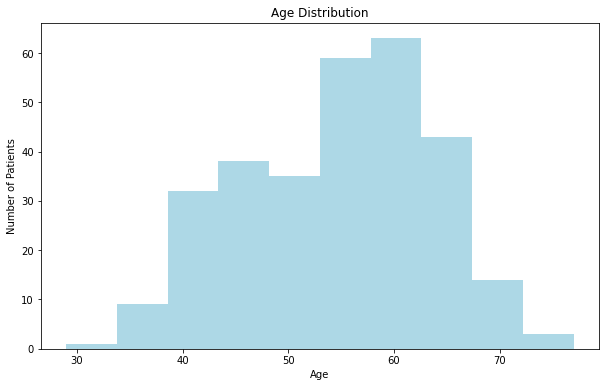

```python
fig, ax = plt.subplots(figsize=(10, 6))
ax.hist(initial_data["age"], color=["lightblue"])
ax.set_xlabel("Age")
ax.set_ylabel("Number of Patients")
ax.set_title("Age Distribution")
plt.show()
```

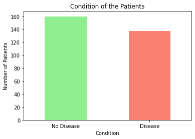

```python
initial_data["condition"].value_counts().plot(kind="bar",
                                              color=["lightgreen","salmon"],
                                              xlabel="Condition",
                                              ylabel="Number of Patients")
plt.xticks([0, 1], ["No Disease", "Disease"], rotation=0)
plt.title("Condition of the Patients");
```

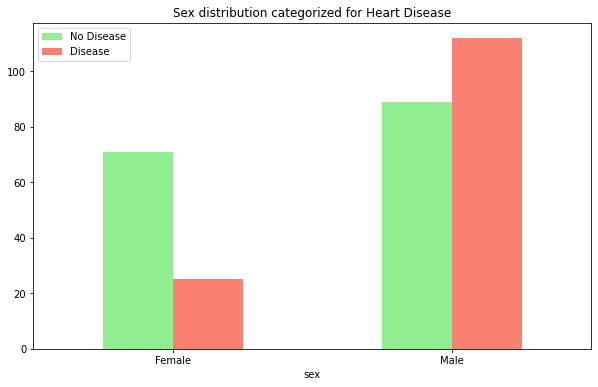

```python
pd.crosstab(initial_data.sex, initial_data.condition).plot(kind="bar", color=["lightgreen", "salmon"], figsize=(10,6))
plt.xticks([0, 1], ["Female", "Male"], rotation=0)
plt.legend(["No Disease", "Disease"])
plt.title("Sex distribution categorized for Heart Disease");
```

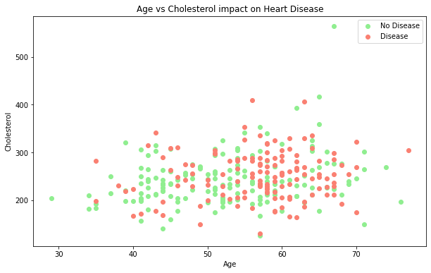

```python
plt.figure(figsize=(10, 6))
plt.scatter(initial_data.age[initial_data.condition==0],
            initial_data.chol[initial_data.condition==0],
            color="lightgreen");
plt.scatter(initial_data.age[initial_data.condition==1],
            initial_data.chol[initial_data.condition==1],
            color="salmon");
plt.title("Age vs Cholesterol impact on Heart Disease")
plt.xlabel("Age")
plt.ylabel("Cholesterol")
plt.legend(["No Disease", "Disease"]);
```

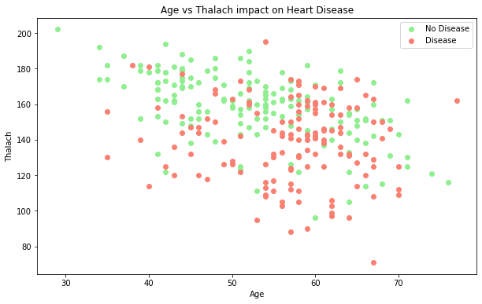

```python
plt.figure(figsize=(10, 6))
plt.scatter(initial_data.age[initial_data.condition==0],
            initial_data.thalach[initial_data.condition==0],
            color="lightgreen");
plt.scatter(initial_data.age[initial_data.condition==1],
            initial_data.thalach[initial_data.condition==1],
            color="salmon");
plt.title("Age vs Thalach impact on Heart Disease")
plt.xlabel("Age")
plt.ylabel("Thalach")
plt.legend(["No Disease", "Disease"]);
```

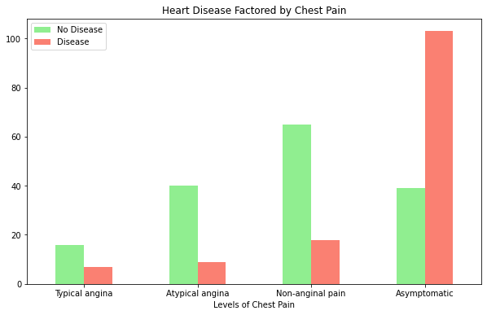

```python
pd.crosstab(initial_data.cp, initial_data.condition).plot(kind="bar",
                                                          color=["lightgreen", "salmon"],
                                                          figsize=(10,6),
                                                          xlabel="Levels of Chest Pain")
plt.xticks([0, 1, 2, 3], ["Typical angina", "Atypical angina", "Non-anginal pain", "Asymptomatic"], rotation=0)
plt.legend(["No Disease", "Disease"])
plt.title("Heart Disease Factored by Chest Pain");
```

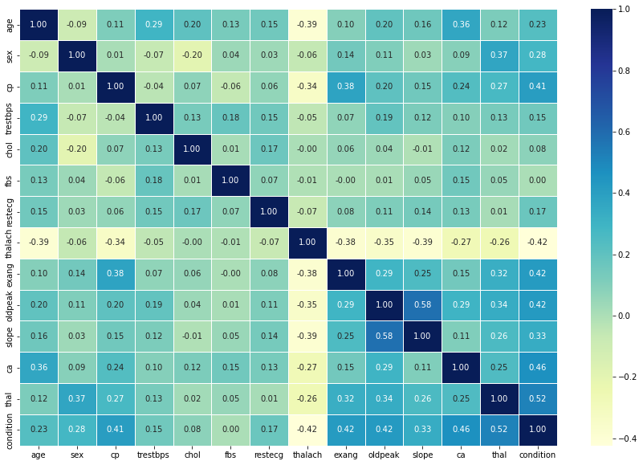

```python
#Correlation Heat Map
fig, ax = plt.subplots(figsize=(15, 10))
ax = sns.heatmap(initial_data.corr(),
                 annot = True,
                 linewidths=0.5,
                 fmt=".2f",
                 cmap="YlGnBu")
```

# 3. Selecting Features for the Classifier

Since the number of potential features is low, we can avoid reducing it further. Usually we would need to reduce the feature list to hasten the model training and testing phase.

```python
from sklearn.model_selection import train_test_split

np.random.seed(7)
X = initial_data.drop("condition", axis=1)
y = initial_data["condition"]
X_train, X_test, y_train, y_test = train_test_split(X, y, test_size=0.2)
```

# 4. Selecting a Classifier

Based on the Scikit learn criteria for selecting a model, https://scikit-learn.org/stable/tutorial/machine_learning_map/index.html, we opt to the following models

- Logistic Regression
- K Neighbors Classifier
- Random Forest Ensemble Classifier

```python
from sklearn.linear_model import LogisticRegression
from sklearn.neighbors import KNeighborsClassifier
from sklearn.ensemble import RandomForestClassifier

trial_models = {"Logistic Regression": LogisticRegression(),
         "KNN": KNeighborsClassifier(),
         "Random Forest": RandomForestClassifier()}
trial_models_score = {}

def clf(model, X_train, X_test, y_train, y_test):
    np.random.seed(7)
    for name, model in trial_models.items():
        model.fit(X_train, y_train)
        trial_models_score[name] = model.score(X_test, y_test)
    return trial_models_score
```

```python
trial_scores = clf(model=trial_models,
                   X_train=X_train,
                   X_test=X_test,
                   y_train=y_train,
                   y_test=y_test)
trial_scores
```

[output not shown]

```
{'Logistic Regression': 0.8833333333333333,
 'KNN': 0.7333333333333333,
 'Random Forest': 0.85}
```

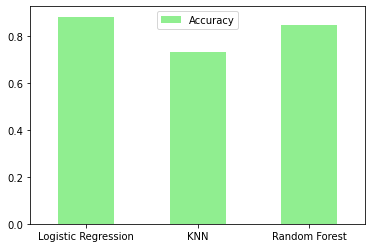

```python
scores = pd.DataFrame(trial_models_score, index=["Accuracy"])
scores.T.plot(kind="bar", color="lightgreen")
plt.xticks(rotation=0);
```

### Tuning the hyperparameters of Logistic Regression and Random Forest Model

```python
from sklearn.model_selection import GridSearchCV
lr_param = {"solver": ["newton-cg", "lbfgs", "liblinear", "sag", "saga"],
            "max_iter": [100, 150, 200, 250, 300]}
rf_param = {"n_estimators": [100, 150, 200],
            "max_depth": [2, 4, 6],
            "min_samples_leaf": [1, 2, 3, 4]}
```

```python
np.random.seed(7)
clf1 = GridSearchCV(estimator=LogisticRegression(),
                    param_grid=lr_param,
                    verbose=2)
clf1.fit(X_train, y_train)
```

```python
clf1.score(X_test, y_test)
```

```
0.8833333333333333
```

```python
np.random.seed(7)
clf2 = GridSearchCV(estimator=RandomForestClassifier(),
                    param_grid=rf_param,
                    verbose=3,
                    cv=5)
clf2.fit(X_train, y_train)
```

```python
clf2.score(X_test, y_test)
```

```
0.9166666666666666
```

# 5. Evaluating the Classifier

Now that we have a prototype model, we need to evaluate its predicting capacity. And for that we use the following metrics:

- Confusion matrix
- Classification Report
- Precision, Recall, f1 scores
- ROC Curve

```python
from sklearn.metrics import confusion_matrix, classification_report
from sklearn.metrics import precision_score, recall_score, f1_score
from sklearn.metrics import RocCurveDisplay
from sklearn.model_selection import cross_val_score
```

```python
predictions = clf2.predict(X_test)
predictions
```

```
array([1, 0, 1, 0, 0, 1, 0, 0, 0, 1, 0, 1, 1, 0, 1, 1, 0, 1, 0, 1, 1, 0,
       0, 0, 0, 0, 0, 1, 1, 0, 0, 0, 1, 1, 0, 0, 0, 0, 0, 1, 0, 0, 1, 1,
       0, 0, 0, 1, 1, 1, 0, 0, 1, 1, 1, 1, 1, 0, 1, 1], dtype=int64)
```

```python
np.array(y_test)
```

```
array([1, 1, 1, 0, 0, 1, 0, 0, 0, 1, 0, 0, 1, 0, 1, 1, 0, 1, 0, 1, 1, 0,
       0, 0, 0, 0, 0, 1, 1, 0, 0, 0, 0, 0, 0, 0, 1, 0, 0, 1, 0, 0, 1, 1,
       0, 0, 0, 1, 1, 1, 0, 0, 1, 1, 1, 1, 1, 0, 1, 1], dtype=int64)
```

```
<sklearn.metrics._plot.roc_curve.RocCurveDisplay at 0x1fb7fb28a60>
```

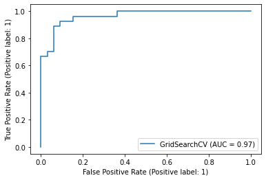

```python
#ROC Curve and AUC value
RocCurveDisplay.from_estimator(clf2, X_test, y_test)
```

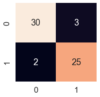

```python
#Confusion Matrix
sns.set(font_scale=1.5)
fig, ax=plt.subplots(figsize=(3,3))
ax = sns.heatmap(confusion_matrix(y_test, predictions),
                 annot=True,
                 cbar=False)
plt.xlabel="True Label"
plt.ylabel="Predicted Label"
```

```python
print(classification_report(y_test,predictions))
```

```
              precision    recall  f1-score   support

           0       0.94      0.91      0.92        33
           1       0.89      0.93      0.91        27

    accuracy                           0.92        60
   macro avg       0.92      0.92      0.92        60
weighted avg       0.92      0.92      0.92        60
```

```python
clf2.best_params_
```

```
{'max_depth': 2, 'min_samples_leaf': 1, 'n_estimators': 200}
```

```python
clf_final = RandomForestClassifier(max_depth=2,
                                   min_samples_leaf=1,
                                   n_estimators=200)
```

```python
np.random.seed(7)
cv_accuracy = cross_val_score(clf_final,
                              X,
                              y,
                              cv=10,
                              scoring="accuracy")
cv_accuracy.mean()
```

```
0.8211494252873563
```

```python
def report(clf, X, y, cv):
    np.random.seed(7)
    parameters = ["accuracy", "precision", "recall", "f1"]
    score_report = {}
    for val in parameters:
        score = cross_val_score(clf, X, y, cv=cv, scoring=val)
        score_report[val]=np.mean(score)
    return score_report
```

```python
score = report(clf_final, X, y, cv=10)
```

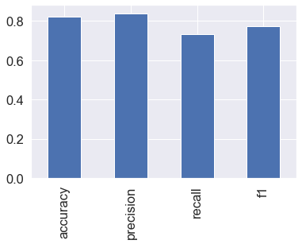

```python
rep = pd.DataFrame(score, index=[0])
rep.T.plot.bar(legend=False);
```

```python
clf2.best_score_
```

```
0.83572695035461
```

```python
clf2.best_estimator_
```

```
RandomForestClassifier(max_depth=2, n_estimators=200)
```

```python
import joblib
joblib.dump(clf2.best_estimator_, "heart_disease_RFC.pkl", compress=1)
```

```
['heart_disease_RFC.pkl']
```